# Szokereso

Zsofi

2018 január 15

## Executive summary

### Importing libraries

```r
library(tidyverse)
library(readxl)
library(reshape2)
library(pastecs)
library(ez)
```

## Read the data

```r
szokereso_data <- read_excel("szokereso_out.xlsx", col_names = TRUE)
```

### Create a new dataset, in which every row is an average of data acquired during the same session

The source of the data is a previous study of our lab. The raw output file gained from the task was processed by a Python script to yield the current file format (which is tidy already). However, in the original file, every measure is calculated for each matrices which were included during the same session, so as first step of the analysis, I made averages for each session of these 5 matrices.

```r
szokereso_session <- szokereso_data %>%
  mutate(session = paste(ID, Stimuláció, Feladat, sep = "_")) %>%
  select(-c(Név, ID, Stimuláció, Feladat)) %>%
  group_by(session) %>%
  summarise_all(.funs = mean) %>%
  separate(col=session, into = c("ID", "Stim", "List"), sep = "_")
```

## Exploring data

The variables were the following: Subject ID which shows participants, Stimulation condition (this was categorical), List (this was also categorical, shows which set of matrices the participant recivied at the given session, it was counterbalanced), Alkalom (this shows how many sessions a participant took), Score (found words weighted with the length of these words), score in percent (this is the same as the other in a practical manner), number of all attempts, number of all words, number of all repetitions, average length of found words,RTs and lengths of the first 3 found words, and a break point in the slope of the RTs of found words. Attempts, number of words, number of repetitions are also broken down to smaller time periods for later analyses (because stimulation can affect specifically the performance in the beginning or in the end of the task). In the current stage of analysis we do not run statistical analyses on those variables, but I still included them in data exploration.

### Boxplots with labeled outliers

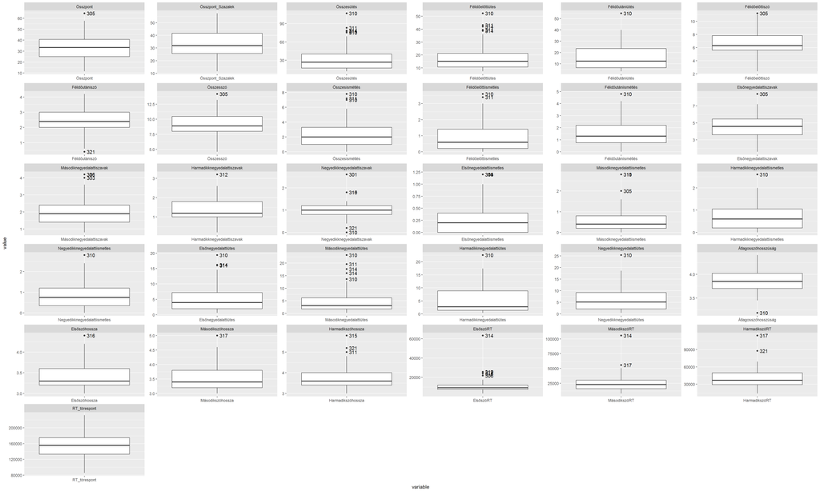

```r
#changing data format to be able to create plots simultaniously to all variables
szokereso_melted <- szokereso_session %>%
  select(-c(List, Alkalom)) %>%
  melt(id.vars = c("ID","Stim"))%>%
  drop_na()

#function for detecting outliers
is_outlier <- function(x) {
  return(x < quantile(x, 0.25) - 1.5 * IQR(x) | x > quantile(x, 0.75) + 1.5 * IQR(x))
}
#applying outlier detecting function to the dataset
szokereso_melted <- szokereso_melted %>%
  group_by(variable) %>%
  mutate(outlier = ifelse(is_outlier(value), ID,""))

#creating the figures
boxplots <- ggplot(data = szokereso_melted, aes(x=variable, y=value)) +
  geom_boxplot() +
  facet_wrap(~ variable, scales = "free") +
  geom_text(aes(label=outlier), hjust=-0.3)
boxplots
```

Based on the boxplots, there are extreme outliers, in case of the RTs in the first 3 found words. Other than that, there are no other extreme outliers, however participant 310 seems to be outlier on several measures, but those are not those that influence the effective performance of participant on the task (not outlier in score of the task, number of found words, but outlier in the number of overall attempts, and repetition). Other participants were not consistently outliers on several measures, thus I did not exclude any participant from all of the analyses based on the boxplots. From the analysis of the first found word’s RT, I excluded participant 314.

### Summary for variables

```r
#overall
summary(szokereso_session)
```

```
##       ID                Stim               List              Alkalom
##  Length:60          Length:60          Length:60          Min.   :1
##  Class :character   Class :character   Class :character   1st Qu.:1
##  Mode  :character   Mode  :character   Mode  :character   Median :2
##                                                           Mean   :2
##                                                           3rd Qu.:3
##                                                           Max.   :3
##
##     Összpont     Összpont_Szazalek   Összesütés     Félidőelőttiütes
##  Min.   :11.60   Min.   :11.61     Min.   : 11.80   Min.   : 7.40
##  1st Qu.:24.95   1st Qu.:25.68     1st Qu.: 17.00   1st Qu.:10.65
##  Median :33.40   Median :32.01     Median : 26.80   Median :15.20
##  Mean   :33.28   Mean   :32.60     Mean   : 34.88   Mean   :18.64
##  3rd Qu.:40.70   3rd Qu.:41.61     3rd Qu.: 40.10   3rd Qu.:21.20
##  Max.   :64.40   Max.   :57.40     Max.   :106.80   Max.   :52.20
##
##  Félidőutániütés Félidőelőttiszó  Félidőutániszó    Összesszó
##  Min.   : 3.40   Min.   : 2.400   Min.   :0.400   Min.   : 4.600
##  1st Qu.: 6.50   1st Qu.: 5.600   1st Qu.:2.000   1st Qu.: 8.000
##  Median :12.40   Median : 6.300   Median :2.400   Median : 8.900
##  Mean   :16.24   Mean   : 6.728   Mean   :2.403   Mean   : 9.132
##  3rd Qu.:23.40   3rd Qu.: 7.800   3rd Qu.:3.000   3rd Qu.:10.450
##  Max.   :54.60   Max.   :11.200   Max.   :4.200   Max.   :14.200
##
##  Összesismétlés  Félidőelőttiismétlés Félidőutániismétlés
##  Min.   :0.000   Min.   :0.0          Min.   :0.000
##  1st Qu.:1.000   1st Qu.:0.2          1st Qu.:0.750
##  Median :2.000   Median :0.6          Median :1.300
##  Mean   :2.427   Mean   :0.9          Mean   :1.527
##  3rd Qu.:3.300   3rd Qu.:1.4          3rd Qu.:2.200
##  Max.   :7.800   Max.   :3.6          Max.   :4.800
##
##  Elsőnegyedalattiszavak Másodiknegyedalattiszavak
##  Min.   :1.60           Min.   :0.800
##  1st Qu.:3.60           1st Qu.:1.400
##  Median :4.60           Median :1.900
##  Mean   :4.72           Mean   :2.008
##  3rd Qu.:5.45           3rd Qu.:2.400
##  Max.   :8.40           Max.   :4.200
##
```

[output cut: 41 more lines]

```
##  Min.   :3.000    Min.   :3.000     Min.   : 3265   Min.   :  7878
##  1st Qu.:3.200    1st Qu.:3.400     1st Qu.: 7424   1st Qu.: 15772
##  Median :3.400    Median :3.600     Median : 9148   Median : 23132
##  Mean   :3.563    Mean   :3.773     Mean   :11309   Mean   : 25535
##  3rd Qu.:3.800    3rd Qu.:4.000     3rd Qu.:11853   3rd Qu.: 30249
##  Max.   :5.000    Max.   :5.800     Max.   :63275   Max.   :105582
##                   NA's   :1
##  HarmadikszóRT     RT_törespont
##  Min.   : 13865   Min.   : 85369
##  1st Qu.: 29047   1st Qu.:133070
##  Median : 36977   Median :155554
##  Mean   : 41157   Mean   :154889
##  3rd Qu.: 49618   3rd Qu.:175232
##  Max.   :114354   Max.   :232336
##  NA's   :1
```

```r
#by different stimulation sessions
by(data = szokereso_session, INDICES = szokereso_session$Stim, FUN = stat.desc, basic =FALSE)
```

```
## szokereso_session$Stim: Bal
##          ID Stim List   Alkalom    Összpont Összpont_Szazalek  Összesütés
## median   NA   NA   NA 2.0000000  31.0000000        30.4710000  27.2000000
## mean     NA   NA   NA 2.1000000  32.7400000        32.4199000  37.8400000
## SE.mean  NA   NA   NA 0.1905670   2.8024463         2.5789957   6.0957725
## CI.mean  NA   NA   NA 0.3988614   5.8655875         5.3979000  12.7585984
## var      NA   NA   NA 0.7263158 157.0741053       133.0243728 743.1688421
## std.dev  NA   NA   NA 0.8522416  12.5329209        11.5336192  27.2611233
## coef.var NA   NA   NA 0.4058293   0.3828015         0.3557574   0.7204314
##          Félidőelőttiütes Félidőutániütés Félidőelőttiszó Félidőutániszó
## median         14.6000000      12.7000000       7.2000000      2.2000000
## mean           20.2100000      17.6300000       7.0300000      2.1700000
## SE.mean         2.9351042       3.2416135       0.3756468      0.1408807
## CI.mean         6.1432438       6.7847750       0.7862378      0.2948667
## var           172.2967368     210.1611579       2.8222105      0.3969474
## std.dev        13.1261852      14.4969362       1.6799436      0.6300376
## coef.var        0.6494896       0.8222879       0.2389678      0.2903399
##          Összesszó Összesismétlés Félidőelőttiismétlés Félidőutániismétlés
## median   9.6000000      1.9000000            0.6000000           1.2000000
## mean     9.2000000      2.4100000            0.9000000           1.5100000
## SE.mean  0.4355275      0.4591697            0.2159435           0.2527637
## CI.mean  0.9115696      0.9610533            0.4519749           0.5290404
## var      3.7936842      4.2167368            0.9326316           1.2777895
## std.dev  1.9477382      2.0534695            0.9657285           1.1303935
## coef.var 0.2117107      0.8520620            1.0730317           0.7486050
##          Elsőnegyedalattiszavak Másodiknegyedalattiszavak
## median                5.1000000                 1.9000000
## mean                  5.1700000                 1.8600000
## SE.mean               0.3054849                 0.1590101
## CI.mean               0.6393873                 0.3328120
## var                   1.8664211                 0.5056842
## std.dev               1.3661702                 0.7111148
## coef.var              0.2642496                 0.3823198
##          Harmadikknegyedalattiszavak Negyedikknegyedalattiszavak
## median                     1.2000000                  1.00000000
## mean                       1.1200000                  1.05000000
## SE.mean                    0.1191196                  0.07521898
## CI.mean                    0.2493201                  0.15743513
## var                        0.2837895                  0.11315789
## std.dev                    0.5327189                  0.33638950
```

[output cut: 238 more lines]

```
## median           3.7000000 9.630200e+03 2.312080e+04  3.737680e+04
## mean             3.7500000 1.168391e+04 2.464943e+04  4.424217e+04
## SE.mean          0.1230105 1.402628e+03 2.436403e+03  5.107081e+03
## CI.mean          0.2574639 2.935734e+03 5.099451e+03  1.068924e+04
## var              0.3026316 3.934730e+07 1.187212e+08  5.216455e+08
## std.dev          0.5501196 6.272742e+03 1.089593e+04  2.283956e+04
## coef.var         0.1466986 5.368701e-01 4.420357e-01  5.162396e-01
##          RT_törespont
## median   1.621379e+05
## mean     1.548475e+05
## SE.mean  6.763326e+03
## CI.mean  1.415580e+04
## var      9.148516e+08
## std.dev  3.024651e+04
## coef.var 1.953310e-01
```

### Normality check by figures - histogram and QQplot

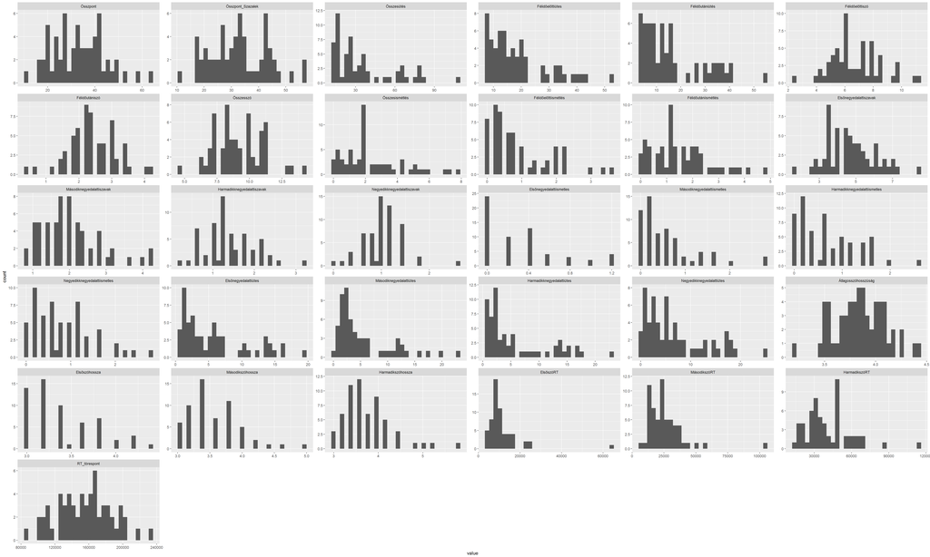

```r
histograms <- ggplot(data = szokereso_melted) +
  geom_histogram(aes(value)) +
  facet_wrap(~ variable, scales = "free")
histograms
```

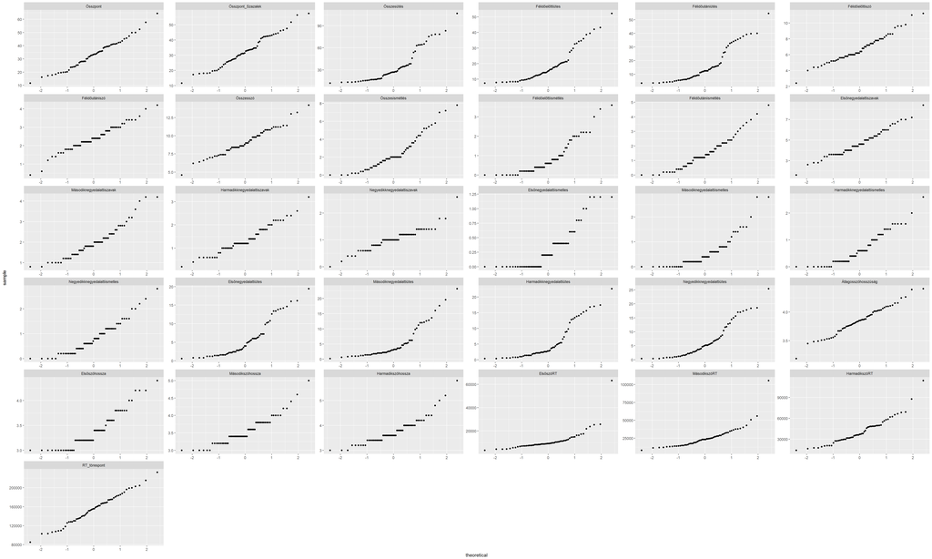

```r
qqs <- ggplot(data = szokereso_melted) +
  geom_qq(aes(sample=value)) +
  facet_wrap(~ variable, scales = "free")

qqs
```

```r
ggsave("boxplots.jpg", boxplots, width = 25, height = 15, dpi = 300)
ggsave("histograms.jpg", histograms, width = 25, height = 15, dpi = 300)
ggsave("qqs.jpg", qqs, width = 25, height = 15, dpi = 300)
```

Based on histograms, and qqplots, some measures are not normally distributed. We can also see that the same measures broken down to smaller time periods have similar distributions.

From here (and for start), we focus on the overall measures.

### Normality check with Shapiro-Wilk test

```r
szokereso_session %>%
  pull(Összpont) %>%
  shapiro.test()
```

```
##
##  Shapiro-Wilk normality test
##
## data:  .
## W = 0.98272, p-value = 0.5537
```

```r
szokereso_session %>%
  pull(Összpont_Szazalek) %>%
  shapiro.test()
```

```
##
##  Shapiro-Wilk normality test
##
## data:  .
## W = 0.97835, p-value = 0.3629
```

```r
szokereso_session %>%
  pull(Összesütés) %>%
  shapiro.test()
```

```
##
##  Shapiro-Wilk normality test
##
## data:  .
## W = 0.83917, p-value = 1.481e-06
```

```r
szokereso_session %>%
  pull(Összesszó) %>%
  shapiro.test()
```

```
##
##  Shapiro-Wilk normality test
##
## data:  .
## W = 0.9803, p-value = 0.4415
```

```r
szokereso_session %>%
  pull(Összesismétlés) %>%
  shapiro.test()
```

```
##
##  Shapiro-Wilk normality test
##
## data:  .
## W = 0.9076, p-value = 0.0002519
```

```r
szokereso_session %>%
  pull(Átlagosszóhosszúság) %>%
  shapiro.test()
```

```
##
##  Shapiro-Wilk normality test
##
## data:  .
## W = 0.98949, p-value = 0.8864
```

```r
szokereso_session %>%
  pull(RT_törespont) %>%
  shapiro.test()
```

```
##
##  Shapiro-Wilk normality test
##
## data:  .
## W = 0.99259, p-value = 0.9749
```

```r
szokereso_session %>%
  pull(Elsőszóhossza) %>%
  shapiro.test()
```

```
##
##  Shapiro-Wilk normality test
##
## data:  .
## W = 0.88577, p-value = 4.142e-05
```

```r
szokereso_session %>%
  pull(Másodikszóhossza) %>%
  shapiro.test()
```

```
##
##  Shapiro-Wilk normality test
##
## data:  .
## W = 0.91407, p-value = 0.0004463
```

```r
szokereso_session %>%
  pull(Harmadikszóhossza) %>%
  shapiro.test()
```

```
##
##  Shapiro-Wilk normality test
##
## data:  .
## W = 0.894, p-value = 9.121e-05
```

```r
szokereso_session %>%
  pull(ElsőszóRT) %>%
  shapiro.test()
```

```
##
##  Shapiro-Wilk normality test
##
## data:  .
## W = 0.59449, p-value = 1.307e-11
```

```r
szokereso_session %>%
  pull(MásodikszóRT) %>%
  shapiro.test()
```

```
##
##  Shapiro-Wilk normality test
##
## data:  .
## W = 0.74422, p-value = 6.994e-09
```

```r
szokereso_session %>%
  pull(HarmadikszóRT) %>%
  shapiro.test()
```

```
##
##  Shapiro-Wilk normality test
##
## data:  .
## W = 0.91194, p-value = 0.0004145
```

Normality was violated in case of variables: Összesütés, Összesismétlés, Első 3 szó hossza, Első 3 szó RT

To be able to still use these variables in a repetead measure ANOVA later, I log-transform these variables, so at least they’ll be symmetrical and can be entered to an ANOVA. After transformation, I checked their distribution with QQ plots again.

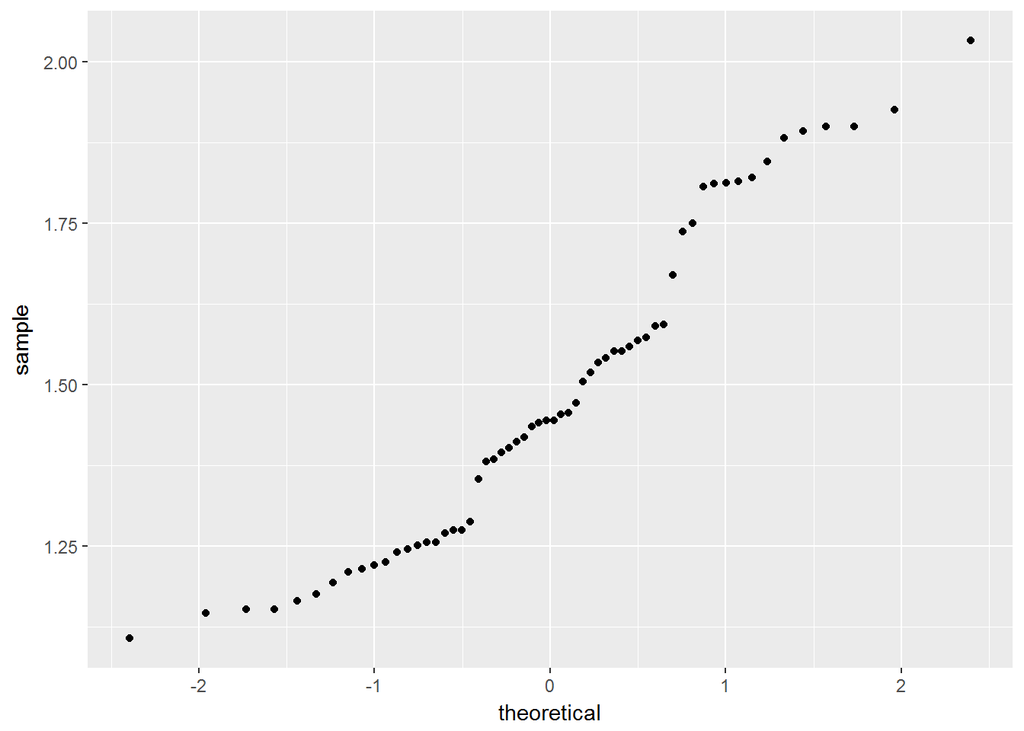

```r
szokereso_session <- szokereso_session %>%
  mutate(tf_osszesutes = log10(Összesütés + 1))

ggplot(data = szokereso_session) +
  geom_qq(aes(sample=tf_osszesutes))
```

```r
szokereso_session %>%
  pull(tf_osszesutes) %>%
  shapiro.test()
```

```
##
##  Shapiro-Wilk normality test
##
## data:  .
## W = 0.93813, p-value = 0.00447
```

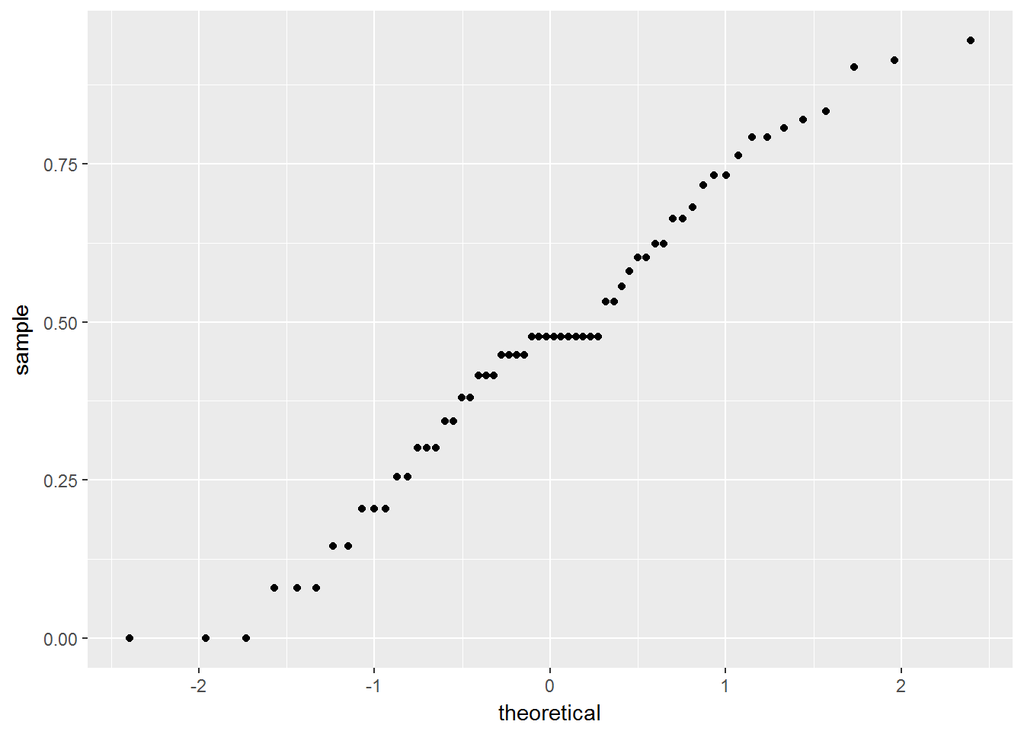

```r
szokereso_session <- szokereso_session %>%
  mutate(tf_osszesism = log10(Összesismétlés + 1))

ggplot(data = szokereso_session) +
  geom_qq(aes(sample=tf_osszesism))
```

```r
szokereso_session %>%
  pull(tf_osszesism) %>%
  shapiro.test()
```

```
##
##  Shapiro-Wilk normality test
##
## data:  .
## W = 0.97529, p-value = 0.2625
```

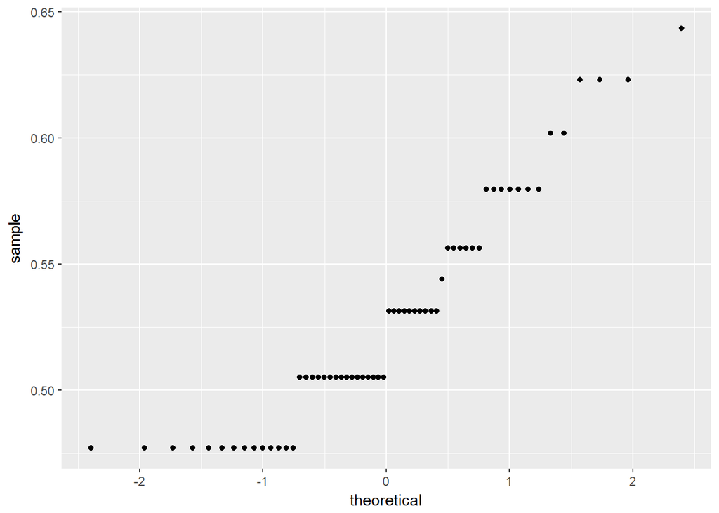

```r
szokereso_session <- szokereso_session %>%
  mutate(tf_length_word1 = log10(Elsőszóhossza))

ggplot(data = szokereso_session) +
  geom_qq(aes(sample=tf_length_word1))
```

```r
szokereso_session %>%
  pull(tf_length_word1) %>%
  shapiro.test()
```

```
##
##  Shapiro-Wilk normality test
##
## data:  .
## W = 0.90015, p-value = 0.0001332
```

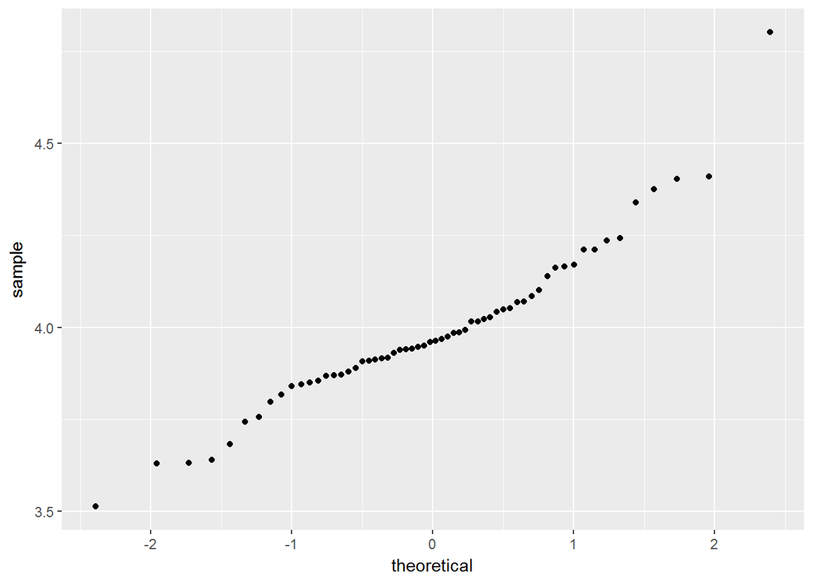

```r
szokereso_session <- szokereso_session %>%
  mutate(tf_elso_RT = log10(ElsőszóRT))

ggplot(data = szokereso_session) +
  geom_qq(aes(sample=tf_elso_RT))
```

```r
szokereso_session %>%
  pull(tf_elso_RT) %>%
  shapiro.test()
```

```
##
##  Shapiro-Wilk normality test
##
## data:  .
## W = 0.94544, p-value = 0.009558
```

Even after data transformation, distributation of overall attempts (Összesütés), length and RTs of the first words still violate normality. However distribution of overall repetition, and the RT and length of the first word were close to symmetrical, so I included these in the ANOVAs.

### Checking Stim differences visually by boxplots

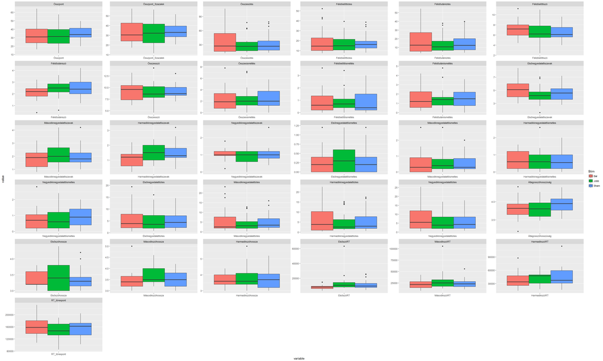

```r
stim_diffs <- ggplot(data = szokereso_melted, aes(x=variable, y=value)) +
  geom_boxplot(aes(fill=Stim)) +
  facet_wrap(~ variable, scales = "free")

stim_diffs
```

```r
ggsave("stim_diffs.jpg", stim_diffs, width = 25, height = 15, dpi = 300)
```

Although I do not see notable differences visually in any of these variables, I tested that statistically.

## Hypothesis

The hypothesis was the following: Frontal stimulation would improve performance on pattern recognition task compared to sham. Further, we expected that right frontal stimulation would improve performance more than left frontal stimulation or sham.

## Data analysis

To compare performance in different sessions, we conducted repeated measures ANOVAs.

```r
score_model <-ezANOVA(data = szokereso_session, dv = .(Összpont), wid = .(ID), within = .(Stim), detailed = TRUE, type = 2)

score_model
```

```
## $ANOVA
##        Effect DFn DFd        SSn      SSd           F            p p<.05
## 1 (Intercept)   1  19 66466.8167 4141.810 304.9076410 3.697052e-13     *
## 2        Stim   2  38   106.8253 2739.308   0.7409467 4.834225e-01
##          ges
## 1 0.90618525
## 2 0.01528709
##
## $`Mauchly's Test for Sphericity`
##   Effect         W         p p<.05
## 2   Stim 0.7985883 0.1321012
##
## $`Sphericity Corrections`
##   Effect       GGe     p[GG] p[GG]<.05       HFe     p[HF] p[HF]<.05
## 2   Stim 0.8323542 0.4614598           0.9026144 0.4711638
```

Condition of sphericity has been met, but the model was not signficant (F(2, 38)= 0.74, p = .48).

```r
words_model <-ezANOVA(data = szokereso_session, dv = .(Összesszó), wid = .(ID), within = .(Stim), detailed = TRUE, type = 2)

words_model
```

```
## $ANOVA
##        Effect DFn DFd          SSn      SSd           F            p p<.05
## 1 (Intercept)   1  19 5003.2401667 131.0565 725.3479466 1.343425e-16     *
## 2        Stim   2  38    0.5203333  67.3130   0.1468711 8.638930e-01
##           ges
## 1 0.961863824
## 2 0.002616189
##
## $`Mauchly's Test for Sphericity`
##   Effect         W         p p<.05
## 2   Stim 0.9538779 0.6537852
##
## $`Sphericity Corrections`
##   Effect       GGe     p[GG] p[GG]<.05      HFe    p[HF] p[HF]<.05
## 2   Stim 0.9559114 0.8549972           1.060279 0.863893
```

Condition of sphericity has been met, but the model was not signficant (F(2, 38)= 0.14, p = .86).

```r
wordslength_model <-ezANOVA(data = szokereso_session, dv = .(Átlagosszóhosszúság), wid = .(ID), within = .(Stim), detailed = TRUE, type = 2)

wordslength_model
```

```
## $ANOVA
##        Effect DFn DFd         SSn      SSd            F            p p<.05
## 1 (Intercept)   1  19 888.9160040 1.366153 12362.744307 3.341066e-28     *
## 2        Stim   2  38   0.2180149 1.958840     2.114661 1.346543e-01
##          ges
## 1 0.99627344
## 2 0.06153384
##
## $`Mauchly's Test for Sphericity`
##   Effect         W         p p<.05
## 2   Stim 0.6243607 0.0144185     *
##
## $`Sphericity Corrections`
##   Effect       GGe     p[GG] p[GG]<.05       HFe     p[HF] p[HF]<.05
## 2   Stim 0.7269347 0.1504364           0.7716057 0.1478679
```

```r
repetition_model <-ezANOVA(data = szokereso_session, dv = .(tf_osszesism), wid = .(ID), within = .(Stim), detailed = TRUE, type = 2)

repetition_model
```

```
## $ANOVA
##        Effect DFn DFd          SSn       SSd           F            p
## 1 (Intercept)   1  19 13.264218153 2.7796729 90.66539594 1.151921e-08
## 2        Stim   2  38  0.003306961 0.6943388  0.09049222 9.136777e-01
##   p<.05          ges
## 1     * 0.7924504709
## 2       0.0009510089
##
## $`Mauchly's Test for Sphericity`
##   Effect         W           p p<.05
## 2   Stim 0.5197344 0.002767153     *
##
## $`Sphericity Corrections`
##   Effect       GGe     p[GG] p[GG]<.05       HFe     p[HF] p[HF]<.05
## 2   Stim 0.6755544 0.8382223           0.7088881 0.8486952
```

```r
word1_length_model <-ezANOVA(data = szokereso_session, dv = .(tf_length_word1), wid = .(ID), within = .(Stim), detailed = TRUE, type = 2)

word1_length_model
```

```
## $ANOVA
##        Effect DFn DFd          SSn        SSd            F            p
## 1 (Intercept)   1  19 16.784720994 0.02306566 1.382617e+04 1.155970e-28
## 2        Stim   2  38  0.004096035 0.09285625 8.381197e-01 4.403609e-01
##   p<.05        ges
## 1     * 0.99314098
## 2       0.03412852
##
## $`Mauchly's Test for Sphericity`
##   Effect         W         p p<.05
## 2   Stim 0.9534096 0.6509022
##
## $`Sphericity Corrections`
##   Effect       GGe     p[GG] p[GG]<.05      HFe     p[HF] p[HF]<.05
## 2   Stim 0.9554836 0.4359863           1.059725 0.4403609
```

Condition of sphericity has been met, but the model was not signficant (F(2, 38)= 0.84, p = .44).

```r
#Excluding outlier
szokereso_session_RT <- szokereso_session %>%
  filter(ID != 314)

word1_RT_model <-ezANOVA(data = szokereso_session_RT, dv = .(tf_elso_RT), wid = .(ID), within = .(Stim), detailed = TRUE, type = 2)

word1_RT_model
```

```
## $ANOVA
##        Effect DFn DFd         SSn       SSd            F            p
## 1 (Intercept)   1  18 902.0475607 0.7122026 22798.084408 2.196402e-29
## 2        Stim   2  36   0.2723028 1.0787799     4.543513 1.739868e-02
##   p<.05       ges
## 1     * 0.9980185
## 2     * 0.1319754
##
## $`Mauchly's Test for Sphericity`
##   Effect         W         p p<.05
## 2   Stim 0.9681226 0.7592905
##
## $`Sphericity Corrections`
##   Effect       GGe      p[GG] p[GG]<.05      HFe      p[HF] p[HF]<.05
## 2   Stim 0.9691074 0.01849707         * 1.084129 0.01739868         *
```

Condition of sphericity has been met, and the model was signficant (F(2, 36)= 4.54, p = .02).

Post-hoc for the significant model.

```r
pairwise.t.test(szokereso_session_RT$tf_elso_RT, szokereso_session_RT$Stim, paired = TRUE, p.adjust.method =
"bonferroni")
```

```
##
##  Pairwise comparisons using paired t tests
##
## data:  szokereso_session_RT$tf_elso_RT and szokereso_session_RT$Stim
##
##      Bal   Jobb
## Jobb 0.029 -
## Sham 0.060 1.000
##
## P value adjustment method: bonferroni
```

The post-hoc test showed that left frontal stimulation is significantly different from right frontal stimulation, and marginally different from sham.

Plot for the model

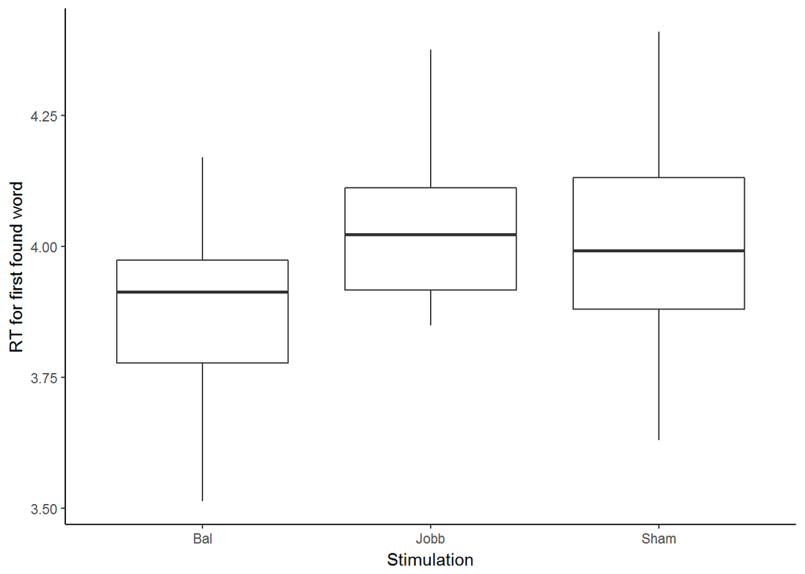

```r
ggplot(data = szokereso_session_RT, aes(x = Stim, y=tf_elso_RT)) +
  geom_boxplot() +
  labs(x = "Stimulation",y = "RT for first found word") +
  theme_classic()
```